# Prediction of Hourly Bike Rental Count Using the Kaggle Bike Sharing Demand Data Set

Adeyemi Arogunmati

June 3, 2016

## Introduction

This document details my exploration of plausible prediction models for the Kaggle Bike Sharing Demand Challenge. Details about the challenge can be found at https://www.kaggle.com/c/bike-sharing-demand. Participants were asked to combine several quantities that could potentially affect the count of bikes rented in the Capital Bikeshare program in Washington, D.C., in order to forecast bike rental demand.

The provided training data set consists of measured and observed data from the first 19 days of each month in 2011 and 2012, with data from the remaining days of the month comprising the testing data set. For each test day, only data from prior days and months will be used to generate its prediction model.

My goal is to use what I learned about relationships between predictor variables and dependence of the outcome variable on predictor variables during exploratory data analysis to create plausible prediction models for the data set.

## Data

The Kaggle Bike Sharing Demand Challenge data set comes in csv format where each row contains the following fields:

- **datetime** - hourly date + timestamp
- **season** - 1 = spring, 2 = summer, 3 = fall, 4 = winter
- **holiday** - whether the day is considered a holiday
- **workingday** - whether the day is neither a weekend nor holiday
- **weather** - 1: Clear, Few clouds, Partly cloudy, Partly cloudy; 2: Mist + Cloudy, Mist + Broken clouds, Mist + Few clouds, Mist; 3: Light Snow, Light Rain + Thunderstorm + Scattered clouds, Light Rain + Scattered clouds; 4: Heavy Rain + Ice Pallets + Thunderstorm + Mist, Snow + Fog
- **temp** - temperature in Celsius
- **atemp** - “feels like” temperature in Celsius
- **humidity** - relative humidity
- **windspeed** - wind speed
- **casual** - number of non-registered user rentals initiated
- **registered** - number of registered user rentals initiated
- **count** - number of total rentals

The count field is the outcome variable given the other fields (predictor variables). In the following sections, I will explore relationships between the outcome variable (count), and the predictor variables.

From the datetime field, we can extract independent year, month, and hour fields. These are variables which had bike rental count trends.

```r
data0 <- read.csv("data_and_codes/train.csv")
```

```r
data0$datetime   = as.POSIXct(data0$datetime, tz = "EST")
data0$year       = factor(format(data0$datetime,"%Y"))
data0$month      = factor(format(data0$datetime,"%m"))
data0$weekday    = factor(format(data0$datetime,"%A"))
data0$hour       = as.POSIXlt(data0$datetime)$hour
data0$holiday    = factor(data0$holiday)
data0$workingday = factor(data0$workingday)
data0$weather    = factor(data0$weather)
data0$atemp      = as.numeric(data0$atemp)
data0$humidity   = as.integer(data0$humidity)
data0$windspeed  = as.numeric(data0$windspeed)
data0$weekday    = factor(as.numeric(!(data0$weekday=="Saturday" | data0$weekday=="Sunday")))
data0$hour       = as.numeric(data0$hour)
```

## Feature Selection

From exploratory data analysis, I learned that there are long-term trends and short-term trends in the data set. Depending on what input data we wish to use in prediction, we may choose to exclude certain variables. For this Kaggle Challenge, participants were required to use only prior data to the data and time of interest in building a prediction model. All training data set were drawn from the 1st to 19th of each month and testing data sets from the 20th to the end of the month. For validation, I have chosen to use data from the 1st to the 15th of each month for model training and 16th to 19th for validation.

I devised three strategies in model building:

- **Strategy 1: Short-term prediction** - Strategy 1 uses only data from the 1st to 15th of each month to build prediction models for that month. This will capture only the most recent short term trends to the date and hour of interest.
- **Strategy 2: Long-term prediction 1** - Strategy 2 uses all available prior data to build prediction models for the date and hour of interest, but does not explicitly use month and year as features. This should capture the most recent short-term as well as the prior long term trends in the data set.
- **Strategy 3: Long-term prediction 2** - Strategy 3 uses all available prior data to build prediction models for the date and hour of interest, and explicitly uses month and year as features. This should capture the most recent short-term as well as the prior long term trends in the data set.

While month and year are excluded in strategies 1 and 2, they are included in strategy 3.

## Model Building

I built prediction models using the earth and random forest methods and the R codes for the three strategies described earlier are shown below:

### Strategy 1 model building code

```r
features <- c("datetime","holiday","workingday","weather","atemp","humidity","windspeed","weekday","hour")
featureCols <- grep(paste0(features,collapse="|"),names(data0))
finalData <- cbind(data.frame(count=data0$count),data0[,featureCols])

months <- c("Jan","Feb","Mar","Apr","May","Jun","Jul","Aug","Sep","Oct","Nov","Dec")
## Modeling
# For validation, we will use data from the 16th to 19th of each month
set.seed(1234)

minTrainDay <- 16
inTrain  <- seq(1,nrow(finalData))[day(ymd_hms(data0$datetime)) < minTrainDay]

training0 <- finalData[inTrain,]
testing0  <- finalData[-inTrain,]

for (cyear in 2011:2012) {
    for (cmth in 1:12) {

        onset1 <- ymd_hms(as.POSIXct(paste0(c(cyear,"-",cmth,"-01 00:00:00"),collapse=""),tz="EST")-1)
        onset2 <- ymd_hms(as.POSIXct(paste0(c(cyear,"-",cmth,"-20 00:00:01"),collapse=""),tz="EST"))

        training <- training0[ymd_hms(training0$datetime) >= onset1 & ymd_hms(training0$datetime) <= onset2,]

        removeCols <- grep("datetime",names(training))
        training <- training[,-removeCols]

        # Train
        tic();fit.rf <- train(count ~ .,method="rf",data=training);toc()
        tic();fit.earth <- train(count ~ .,method="earth",data=training);toc()

        # Save model to disk
        prefix <- "data_and_codes/saved_models_permonth/fit."
        suffix <- c(cyear,"_",months[cmth],".RData")

        filename <- paste0(c(prefix,"rf",".",suffix),collapse="")
        save(fit.rf,file=filename)

        filename <- paste0(c(prefix,"earth",".",suffix),collapse="")
        save(fit.earth,file=filename)
    }
}
```

### Strategy 2 model building code

```r
features <- c("datetime","holiday","workingday","weather","atemp","humidity","windspeed","weekday","hour")

featureCols <- grep(paste0(features,collapse="|"),names(data0))
finalData <- cbind(data.frame(count=data0$count),data0[,featureCols])
months <- c("Jan","Feb","Mar","Apr","May","Jun","Jul","Aug","Sep","Oct","Nov","Dec")

## Modeling
# For validation, we will use data from the 16th to 19th of each month
set.seed(1234)

minTrainDay <- 16
inTrain  <- seq(1,nrow(finalData))[day(ymd_hms(data0$datetime)) < minTrainDay]

training0 <- finalData[inTrain,]
testing0  <- finalData[-inTrain,]

for (cyear in 2011:2012) {
  for (cmth in 1:12) {

    onset <- ymd_hms(as.POSIXct(paste0(c(cyear,"-",cmth,"-20 00:00:01"),collapse=""),tz="EST"))
    training <- training0[ymd_hms(training0$datetime) <= onset,]

    removeCols <- grep("datetime",names(training))
    training <- training[,-removeCols]

    # Train
    tic();fit.rf <- train(count ~ .,method="rf",data=training);toc()
    tic();fit.earth <- train(count ~ .,method="earth",data=training);toc()

    # Save model to disk
    prefix <- "data_and_codes/saved_models_accumulate/fit."
    suffix <- c(cyear,"_",months[cmth],".RData")

    filename <- paste0(c(prefix,"rf",".",suffix),collapse="")
    save(fit.rf,file=filename)

    filename <- paste0(c(prefix,"earth",".",suffix),collapse="")
    save(fit.earth,file=filename)
  }
}
```

### Strategy 3 model building code

```r
features <- c("datetime","year","month","holiday","workingday","weather","atemp","humidity","windspeed","weekday","hour")

featureCols <- grep(paste0(features,collapse="|"),names(data0))
finalData <- cbind(data.frame(count=data0$count),data0[,featureCols])

months <- c("Jan","Feb","Mar","Apr","May","Jun","Jul","Aug","Sep","Oct","Nov","Dec")

## Modeling
# For validation, we will use data from the 16th to 19th of each month
set.seed(1234)

minTrainDay <- 16
inTrain  <- seq(1,nrow(finalData))[day(ymd_hms(data0$datetime)) < minTrainDay]

training0 <- finalData[inTrain,]
testing0  <- finalData[-inTrain,]

for (cyear in 2011:2012) {
  for (cmth in 1:12) {

    onset <- ymd_hms(as.POSIXct(paste0(c(cyear,"-",cmth,"-20 00:00:01"),collapse=""),tz="EST"))
    training <- training0[ymd_hms(training0$datetime) <= onset,]

    removeCols <- grep("datetime",names(training))
    training <- training[,-removeCols]

    # Train
    tic();fit.rf <- train(count ~ .,method="rf",data=training);toc()
    tic();fit.earth <- train(count ~ .,method="earth",data=training);toc()

    # Save model to disk
    prefix <- "data_and_codes/saved_models_accumulate_wmthyr/fit."
    suffix <- c(cyear,"_",months[cmth],".RData")

    filename <- paste0(c(prefix,"rf",".",suffix),collapse="")
    save(fit.rf,file=filename)

    filename <- paste0(c(prefix,"earth",".",suffix),collapse="")
    save(fit.earth,file=filename)
  }
}
```

## Results

Once models have been built, we can assess results by examining the prediction errors of our models. In this case, I choose to use the root mean square error (rmse). Scatter plots of out-of-sample error vs in-sample error can help examine the performance of our models. As much as I want our models to have very low in-sample errors, I would also like my out-of-sample error to be close to my in-sample error since one of my assumptions is that the outcome variables all come from the same distribution so any errors in predicting one subset of it should be close to errors in predicting another subset of it. I want the in-sample error to my expected out-of-sample error.

### Strategy 1

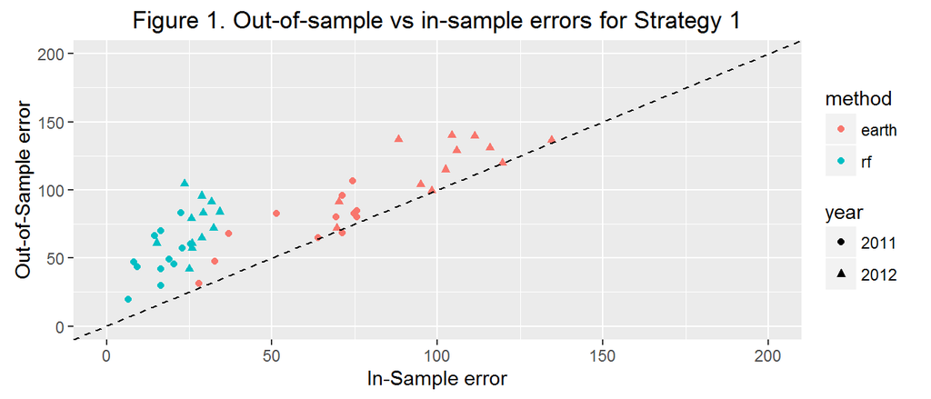

Figure 1 shows that for all 24 months predicted, random forest out-performs earth method, however, in-sample errors better reflect out-of-sample errors using the earth method.

### Strategy 2

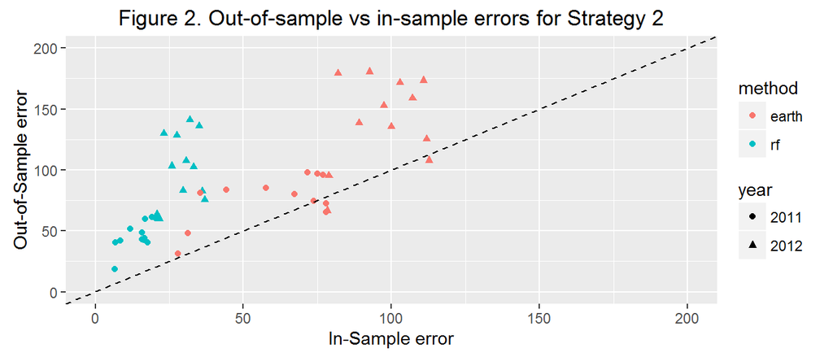

### Strategy 3

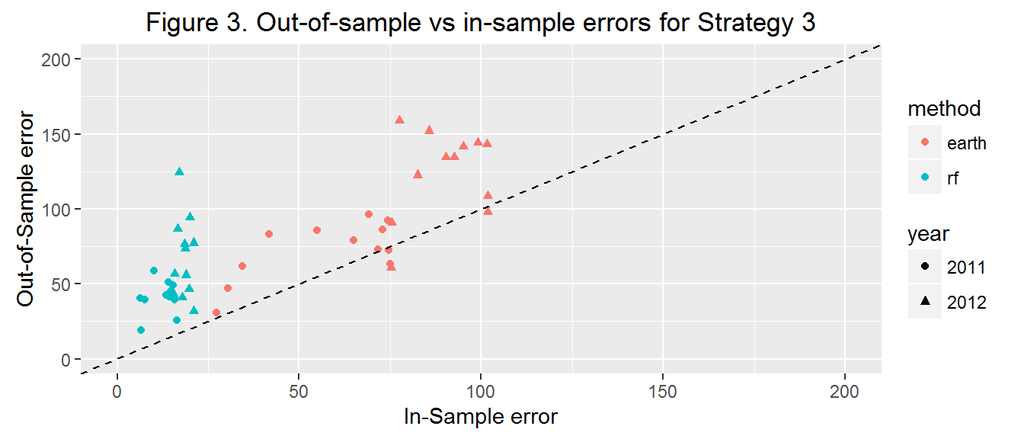

We can see in Figure 3 that using year and month as features in long-term prediction improves both in-sample and out-of-sample errors overall.

### Strategy comparison

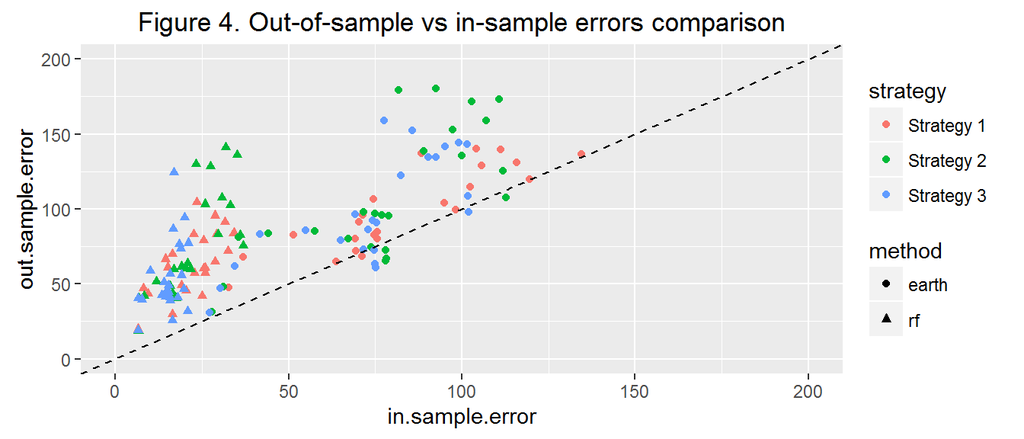

Of the three strategies discussed, Strategy 2 seems to perform worst. There are pros and cons to using Strategies 1 and 3. With Strategy 1, in-sample error better reflect out-of-sample error but in-sample errors are slightly larger. However, with Strategy 3, in-sample errors are slightly lower but are not as good as the in-sample errors from Strategy 1 in reflecting the out-of-sample errors.

### Sample prediction plots

Plots of examples of training data and validation data predictions are shown below.

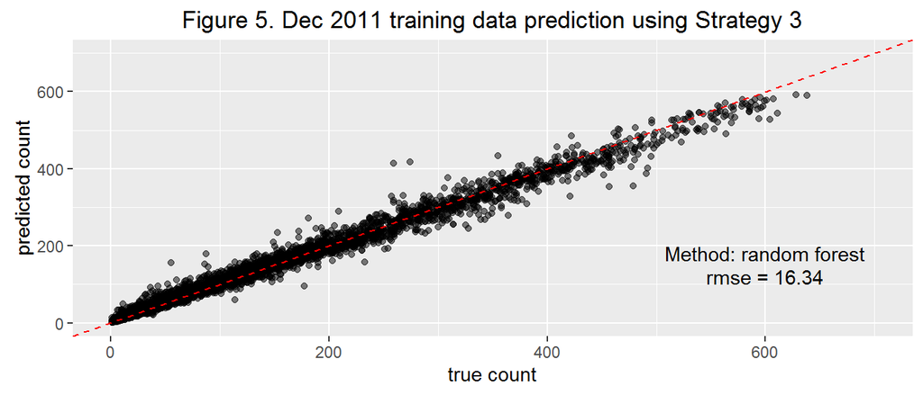

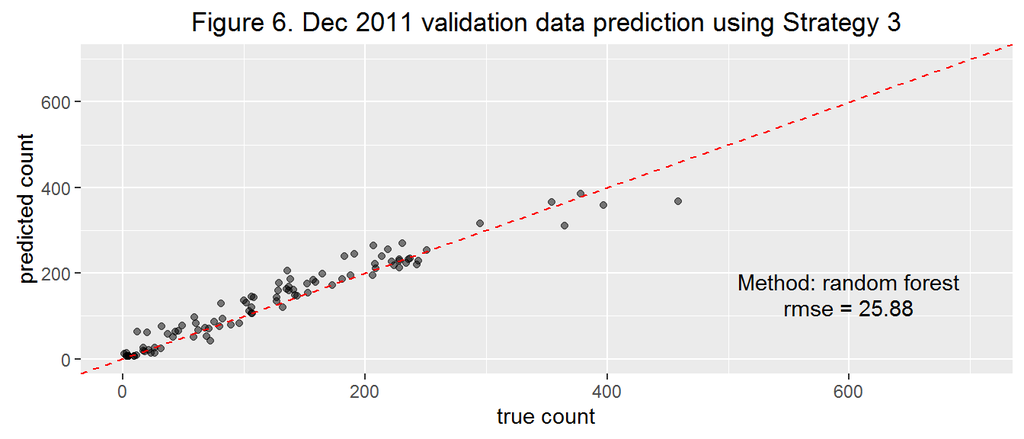

## Conclusions

Using knowledge gained by exploratory data analysis, I devised three strategies for building prediction models for bike rental count from provided historical data. Strategies differed based on how much of the historical data are used in prediction. If only recent data (< 3 weeks) are used, it is unnecessary to include features for month and year. However if all historical data are to be used, it is necessary to include month and year so as to capture and account for the long-term trends in the bike rental. If these are not included, larger prediction rms errors will be obtained.

## Recommendations

While I have trained my hourly bike rental count predictors using similar algorithm tuning parameters for each month, better results can be obtained if models are trained using tuning parameters best suited for the historical data available for each month independently. In other words, when training your model for the month in question, tuning parameters that produce the best in-sample and out-of-sample errors should be used.